# PS 7 Solution

Gov 1005

Read [how we grade problem sets](https://www.davidkane.info/post/2019-08-31-problem-sets-and-exams/).

**Objectives for this problem set:**

- Students will practice conducting **exploratory data analysis**
- Students will **demonstrate their understanding** of basic concepts in regression, correlation and causation
- Students will **practice running regressions**

For this pset, we’re going to use the database of DW-Nominate scores. We suggest reading about the data here. At its core, the data seeks to use data about legislators’ choices (in this case, roll-call voting) to “map” legislators’ ideological positions.

Create a data directory and place a csv file of the data there. (Note how we are no longer telling you precisely what to do. There are a variety of reasonable approaches! Part of becoming a data scientist is learning to make sensible choices for yourself. The only requirement is that, when we knit your Rmd, we get your html.) The data you want is the default set up that first appears when you go to [the page](https://voteview.com/data): Data Type is Member Ideology; Chamber is Both; Congress is All; and File Format is CSV. Read about [what the variables mean](https://voteview.com/articles/data_help_members).

From the VoteView information page, “the primary dimension through most of American history has been”liberal" vs. “conservative” (also referred to as “left” vs. “right”). A second dimension picks up differences within the major political parties over slavery, currency, nativism, civil rights, and lifestyle issues during periods of American history." For this problem set, we’re going to focus on where members of congress fall on dimension 1, listed in the data as `nominate_dim1`

## Question 1: Conduct exploratory data analysis

### 1A) Summary Statistics

We’re going to examine the hypothesis that older senators are more conservative.

Let’s just use the data for Senators (chamber == “Senate”) and Representatives (chamber == “House”) in the 116th Congress. Create a new variable `party` with values “Democrat” and “Republican.” Drop the independents. Create a new variable `age` which is 2019 (when the 116th Congress was sworn in) minus birth year. Create a new variable called `nominate_percentile` which is the percentile rank of `nominate_dim1`, where 50 is someone at the 50th percentile.

Note that

- party_code 328 represents independents
- party_code 100 represents democrats
- party_code 200 represents republicans

Using the `skimr` package, print the output of calling `skim` on your `nominate_percentile` and `age` variables.

### 1B) Visualizing a single variable

Make a nice plot (histogram or bar chart) showing the distribution of congressional ages. Feel free to be creative- maybe you want to show the distribution by party or chamber. Remember, we’re using this process to explore the data; try and make a plot that helps you understand it better. Then, do the same for your outcome variable, `nominate_percentile.` Print both plots here.

### 1C) Bivariate Correlations

Remember that our end goal is not to understand just a single variable, but how they relate to one another. *Bivariate correlations* help us to understand the relationship between two variables. Within your dataset of the 116th congress, calculate the **correlation coefficient** between `age` and `nominate_percentile`. Print the result here. In one sentence, tell us how we would interpret a *negative* coefficient vs. a *positive* coefficient.

### 1D) Plotting Bivariate relationships

Replicate the plot below by doing the following.

Make a scatterplot of the relationship between `age` and `nominate_percentile`. Color each point based on the member’s party. Add a black “best fit” line (use `geom_smooth(method = "glm")`) to illustrate the relationship between age and DW nominate percentile. Does the direction of your line match the sign of your correlation coefficient? Then, add two more best fit lines, a red and a blue, for the relationship within parties.

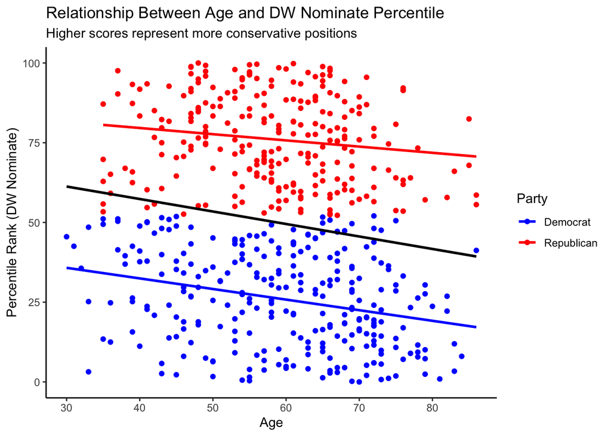

## Question 2: Run a single regression

### 2A) Using lm()

Now that we’ve explored our data, we want to transition to systematically testing the relationship between our variables of interest, age and DW nominate percentile rank. The plot in 1D shows us that while the direction of the relationship seems constant across both parties, the fitted values will likely be very “noisy” if we calculate averages across all of congress. Thus, for the rest of the problem set, we’re going to subset the data to only consider democrats.

Subset your data for the 116th congress to just democrats (party_code = 100).

Run a linear regression of `nominate_percentile` on `age`, using `lm`. Tidy up your data, calling `term`, `estimate`, `conf.low`, and `conf.high`. Print a gt table with these values. Your table should look like something like this.

Effect of Age on DW Nominate Percentile

| Higher percentile suggests more conservative Variable | Higher percentile suggests more conservative Estimate | Higher percentile suggests more conservative Lower bound | Higher percentile suggests more conservative Upper bound |
| --- | --- | --- | --- |
| (Intercept) | 45.7469111 | 37.4458230 | 54.0479993 |
| age | -0.3322965 | -0.4687675 | -0.1958254 |

### 2B) Interpreting results

In one or two paragraphs (max 200 words), answer the following.

- What is the estimated **average treatment effect?** How would you, in words, describe the effect of being one year older on a democratic member of congress’s percentile rank for DW nominate scores?
- Give one reason we should not necessarily interpret the estimated correlation as causal. In other words, can you think of a reason that older democratic senators might be less conservative, *that is not a direct effect of age*?
- Why do we calculate a confidence interval around our average treatment effect?

### 2C) Regression and the Rubin Causal Model

We might want to know whether conducting military service makes congress members more or less conservative. Imagine that we have the power to randomly assign the democratic members of congress to active military duty, and then we observe their roll call voting records (and calculate their DW nominate score) afterward. Our data would then have a **treatment** variable `military` which would take values of `treated` or `control`, and the same **outcome** variable, `nominate_percentile`. Our potential outcomes table would look like this:

Potential Outcomes for DW Nominate Percentile<sup>1</sup>

| Member of Congress | Military | Potential Outcomes Under Control | Potential Outcomes Under Treatment |
| --- | --- | --- | --- |
| SEWELL, Terri | Treatment | ? | 21.83 |
| GRIJALVA, Raúl M. | Control | 2.05 | ? |
| KIRKPATRICK, Ann | Treatment | ? | 49.63 |
| GALLEGO, Ruben | Treatment | ? | 11.19 |
| O'HALLERAN, Thomas C. | Control | 47.57 | ? |
| STANTON, Greg | Treatment | ? | 34.89 |
| PELOSI, Nancy | Treatment | ? | 7.28 |
| SCHIFF, Adam | Treatment | ? | 29.48 |
| DAVIS, Susan A. | Control | 30.41 | ? |
| SÁNCHEZ, Linda T. | Control | 6.34 | ? |

<sup>*1*</sup> Treatment is military service

Note that we’re just using the observed nominate percentiles, and imagining that the treatment had been assigned prior.

Now imagine that we ran the following code:

```r
mil_model <- lm(nominate_percentile ~ military, data = d116)
```

In a short paragraph (100 words or fewer), explain how you would interpret the coefficient on `military` within the framework of the Rubin Causal Model. You may want to see the discussion in 11.1.3 in PPBDS for help. Make sure to use the phrases “average treatment effect” and “difference in potential outcomes” and to explain whether this analysis could be considered causal or not (hint- the randomization is what matters).

## Question 3: Generalize to many regressions

Let’s return to our question of the relationship between age and conservatism in congress, but look at the entire sample, not just the 116th congress. We’ll continue to subset to only democratic members of congress. We’re going to replicate the plot below, which shows how the estimate and confidence interval for the effect of age on conservativism for democrats changes across congresses.

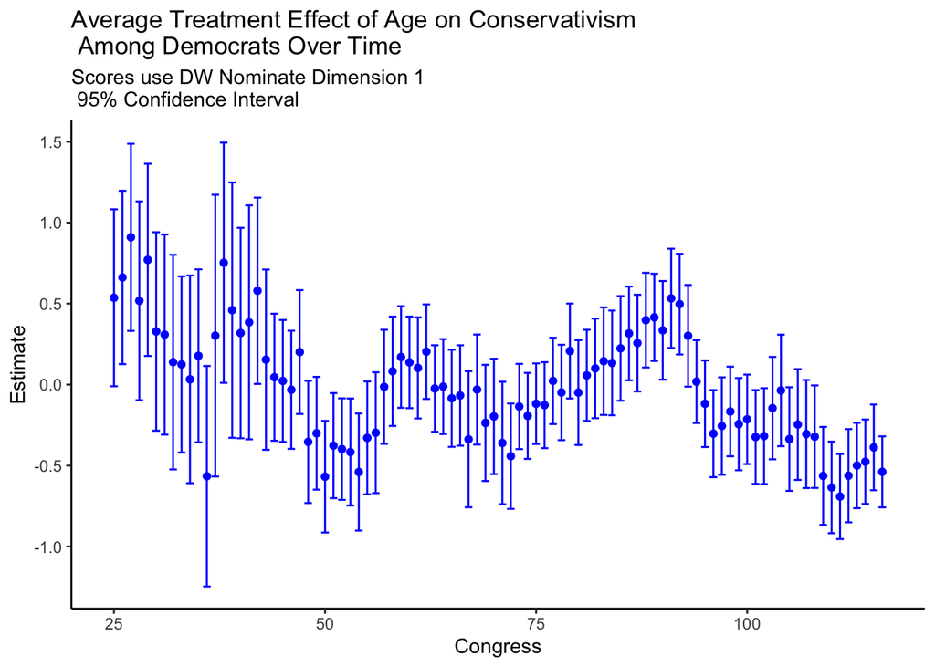

Your resulting tibble should have eight columns:

- congress
- data
- mod
- reg_results
- coef
- se
- upper
- lower

You can use this tibble to create the plot above. The X axis shows the number congress, while the y axis shows the average treatment effect (coef) of age on nominate_percentile that year. We used `geom_errorbar(aes(x = congress, ymin = lower, ymax = upper))` + to produce the 95% confidence intervals on the estimates.